# TT Overall Overview

# Load the data and set flags

(code hidden)

```
## [1] "QC filter? TRUE"
```

```
## [1] "Which pilot paradigm? 1"
```

Participants and counterbalancing

| counterbalancing | prolific_id | n |
| --- | --- | --- |
| dense_left | sub_01 | 1 |
| dense_left | sub_03 | 1 |
| dense_left | sub_05 | 1 |
| dense_left | sub_08 | 1 |
| dense_left | sub_10 | 1 |
| dense_left | sub_12 | 1 |
| dense_left | sub_14 | 1 |
| dense_left | sub_16 | 1 |
| dense_right | sub_02 | 1 |
| dense_right | sub_04 | 1 |
| dense_right | sub_06 | 1 |
| dense_right | sub_07 | 1 |
| dense_right | sub_09 | 1 |
| dense_right | sub_11 | 1 |
| dense_right | sub_13 | 1 |
| dense_right | sub_15 | 1 |

# Plots over all trials

Show data for Pre, post, and post-minus-pre difference. Also, show combined data and broken down by the two counterbalancing conditions (dense_left and dense_right).

These plots do not address the questions we’re interested in, because they average over all types of triplets from all templates located anywhere along the dimension.

But its good to see that accuracy is alright: around 75% pre and post.

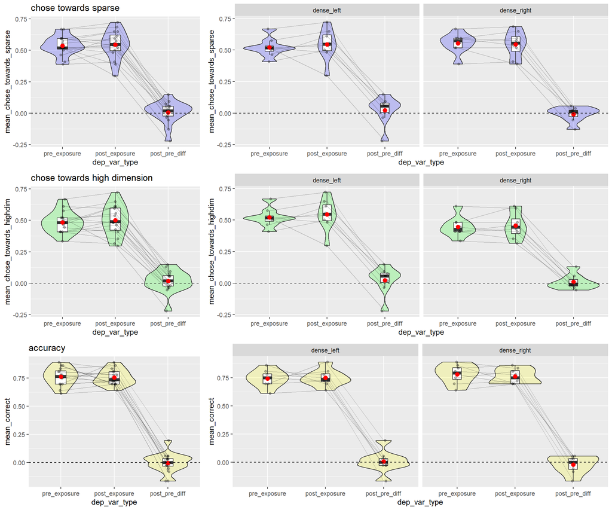

# Plots over triplet location

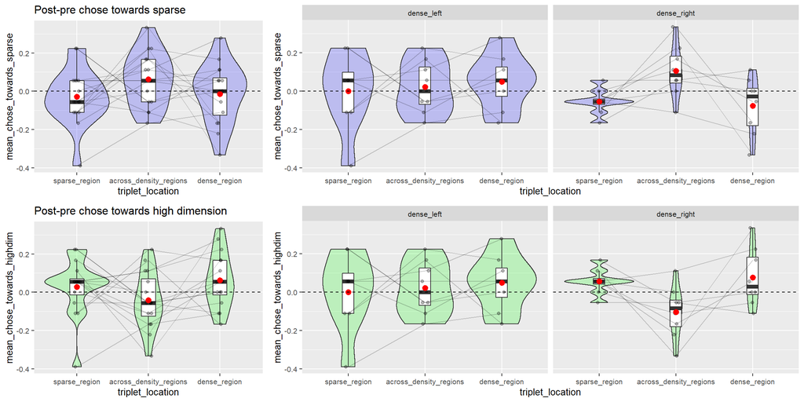

## Plot the difference between the triplet locations

Here, I take the difference between the triplets located in the various density regions. We want across_minus_dense or across_minus_sparse to be above 0.

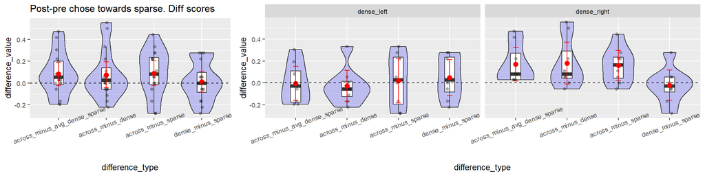

# Plots over triplet location and easiness

We have 3 levels of “easiness” in our TEMPlates.

- Easiness = 0: these are symmetric templates, where both referents are equally distant from the query.
- Easiness = 8: here, the distance(query,ref1) is 8 units larger than distance(query,ref2). So its easier to see which refs is closer
- Easiness = 16: here, its even more easy to see which ref is closer to query.

So, its useful to check which of these templates are driving the overall effects we see above.

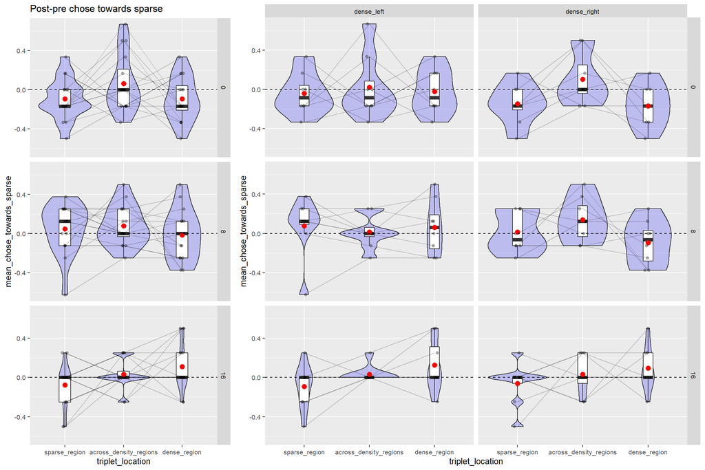

## Plot the difference between triplet locations for each easiness level

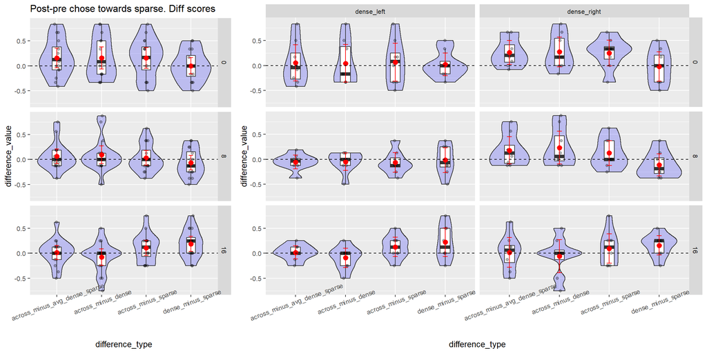

# Plots for each easiness level: triplet location by template

For each easiness level, we have several types of templates. So the plots below simply further break down the plots from the previous panel, plotting data for each template separately.

This is just in case there is a really strong signal showing us that one of the templates is really great while others not.

```
## [1] "0"
```

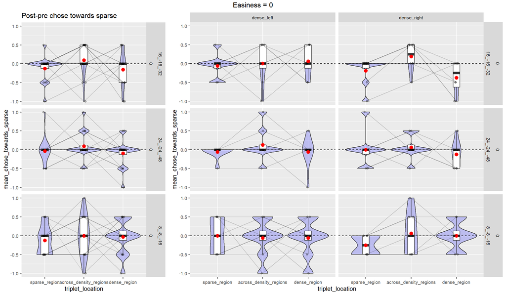

```
## [1] "8"
```

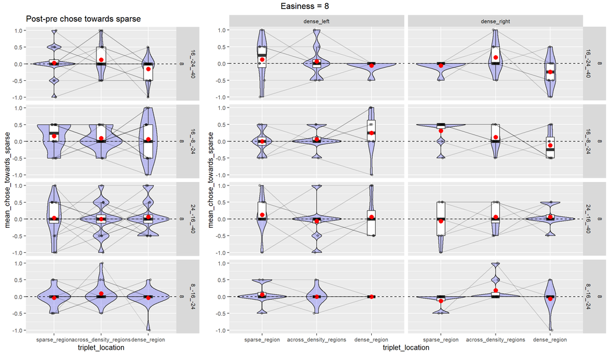

```
## [1] "16"
```

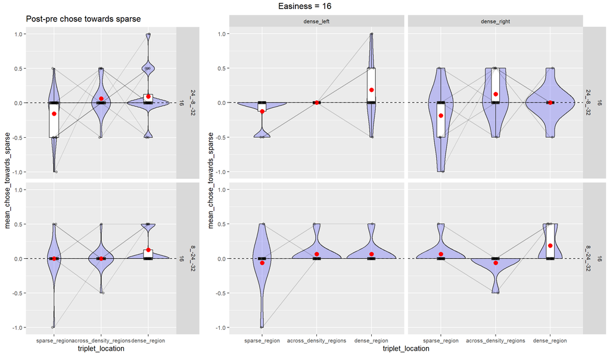

# Between participant comparisons:

We’ve already seen these in sections above, where I break it down by dense_left vs dense_right.

But its useful to plot the data from the two counterbalancing groups next to each other, along with 95% confidence intervals for a quick eye-balling of stats.

## Averaging over all triplets:

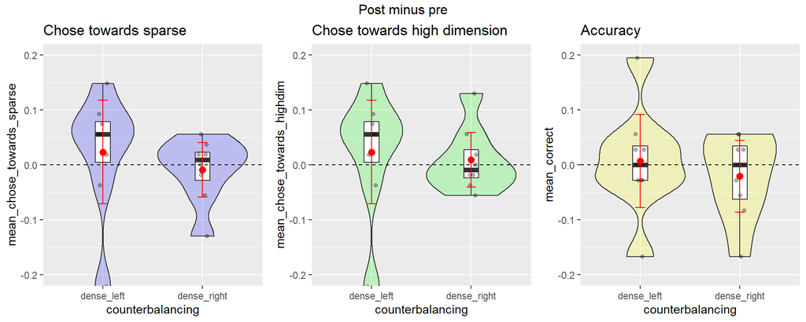

## Triplet location

If density stretches the psychological space then what we want to see below is the following:

- The probability of choosing towards sparse should increase for both counterbalancing groups.
- The prob of choosing highdimensional referent should increase for dense_left and decrease for dense_right.

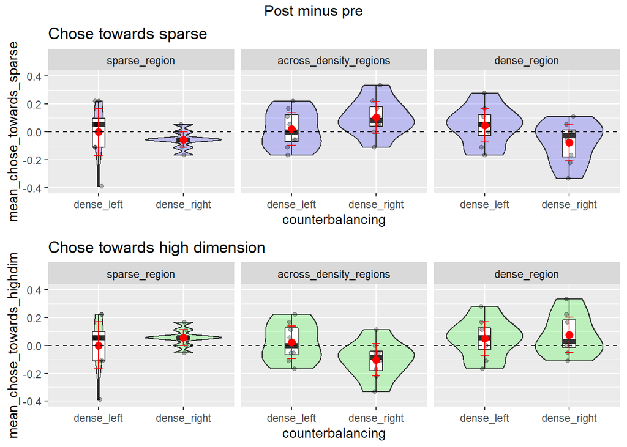

## Triplet location by template breakdown:

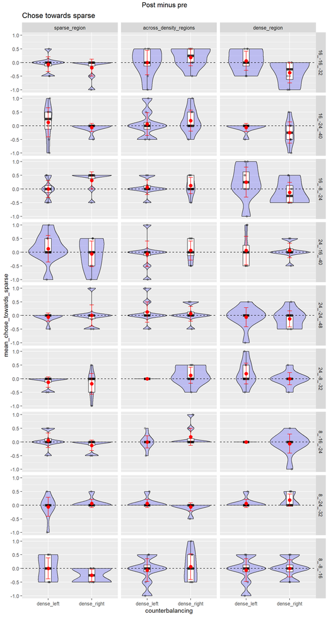